# The One Piece: Dataset

2026-04-08

## Project Overview:

- Exploring patterns in the One Piece world
- Focusing on bounties, characters, Devil Fruits, Islands, and episodes.

## Introduction

- One piece is a long running anime (1999) and manga series
- The world full of pirates, crews, bounties, and adventures
- Using data science to explore and uncover patterns in this universe.

## Background Information

One piece is a long time running (1999) anime/ manga about pirates looking for the One Piece, the greatest treasure in the world.

The show follows the Strawhat Crew, with the main character being Monkey D. Luffy, along with his friends including Zoro, Sanji, Nami, Brook, Robin, Jinbe, & Chopper.

One Piece is essentially about pirate crews exploring different regions and competing for power, fame, and treasure. (And for Luffy to make friends along the way)

## What is a “Crew”?

A crew is a team of pirates Each crew has: - Captain (Leader of the group) - Members with roles (Navigator, Doctor, etc.)

## What is a “Bounty”?

- A bounty is a price put on the head of certain individuals, typically pirates.
- the higher the bounty, the more dangerous the world government identifies you as

## Tidying Data

- Lots of cleaning up
- Some things were in french…
- nested dataframes
- and yea

> Join characters with crew df

Devil Fruit joined with the rest of the DF

## Bounty

## What influences Bounty?

In One Piece, the more chaos you cause, the higher the bounty on your head is. The bounties reflect how dangerous each pirate is.

## Does Age Influence Bounty?

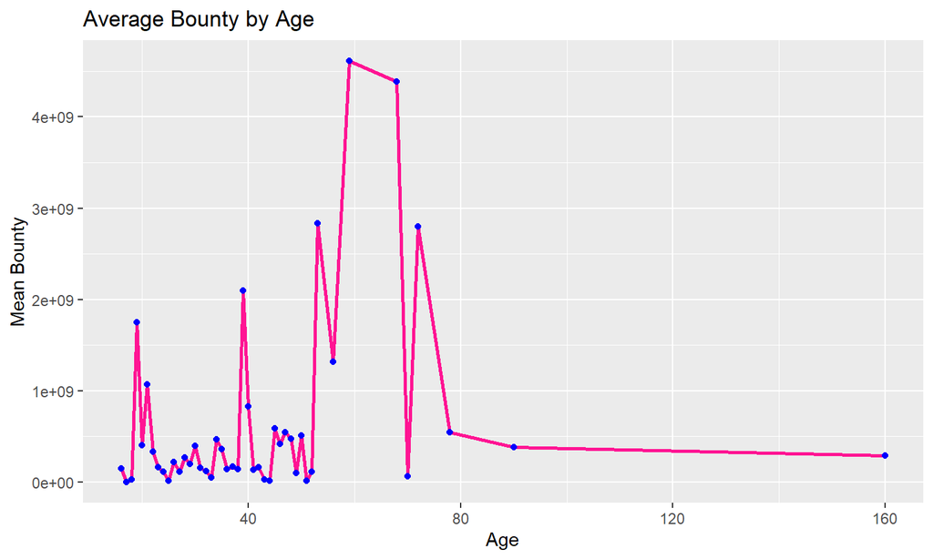

## How Many Characters Have a Bounty?

Bounty Summary

| total | with_bounty | without_bounty | pct_with_bounty |
| --- | --- | --- | --- |
| 786 | 141 | 645 | 17.9% |

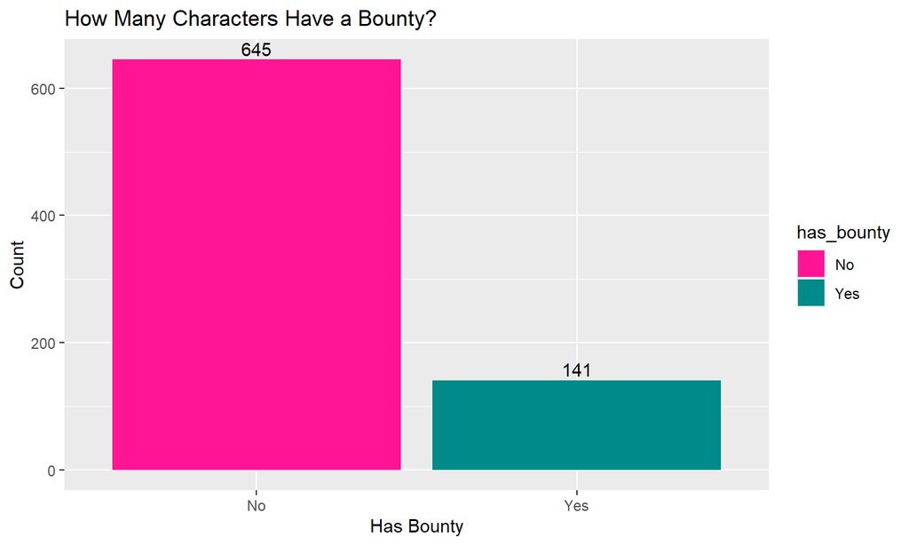

## Average Bounty Overall?

```
##   avg_bounty
## 1  439963557
```

## Top Crews by Bounty?

```
##                 crew_name crew_total_prime
## 1 The Hundred Beasts crew      11179100000
## 2          Big Mom's crew      11121500000
## 3       Whitebeard's crew       7480000000
## 4  The Pirates Roger crew       5564800000
## 5        Red Hair Pirates       4142900000
```

## Crew Bounty (plot)

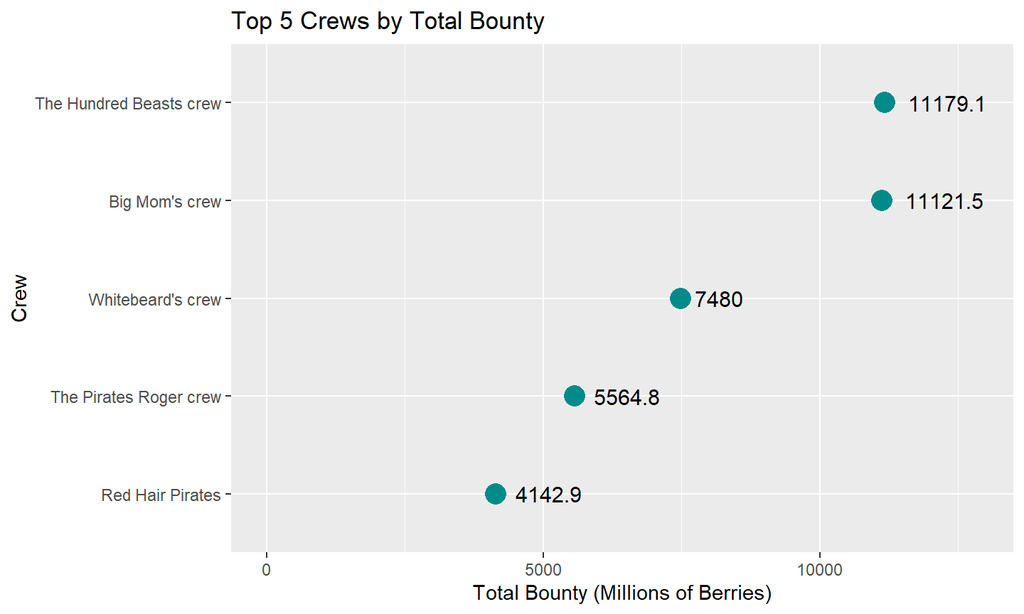

## Bubble Plot

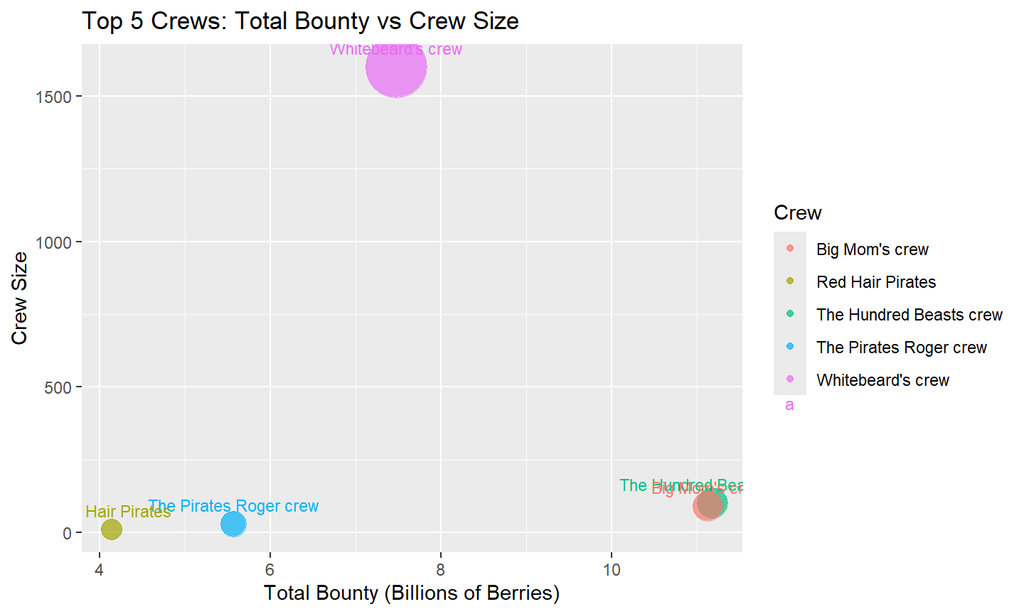

## Captain vs Fighter Bounties

| job | avg_bounty | count |
| --- | --- | --- |
| Captain | 1004425333 | 45 |
| Fighter | 356800000 | 9 |

## Devil Fruits

## Why Study Devil Fruits?

- Known to be rare and powerful
- May influence strength and reputation
- We wanted to see how they appear in the data

## Characters With vs Without Devil Fruits

- Shows how many characters have Devil Fruits
- Majority of characters do not have one

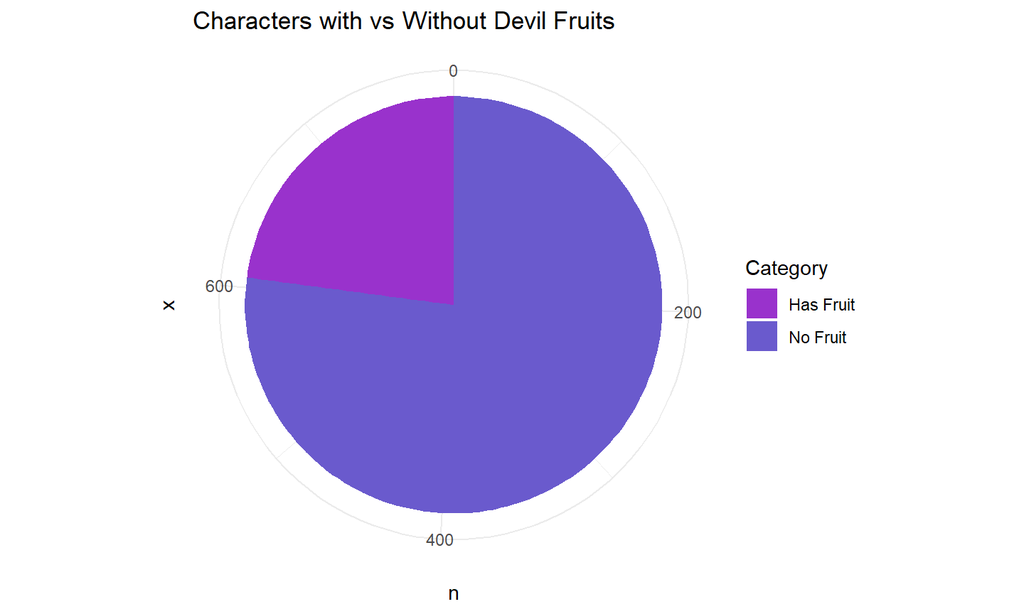

## Bar Graph (Correct Graph)

- Compared to the circle graph, this one is better

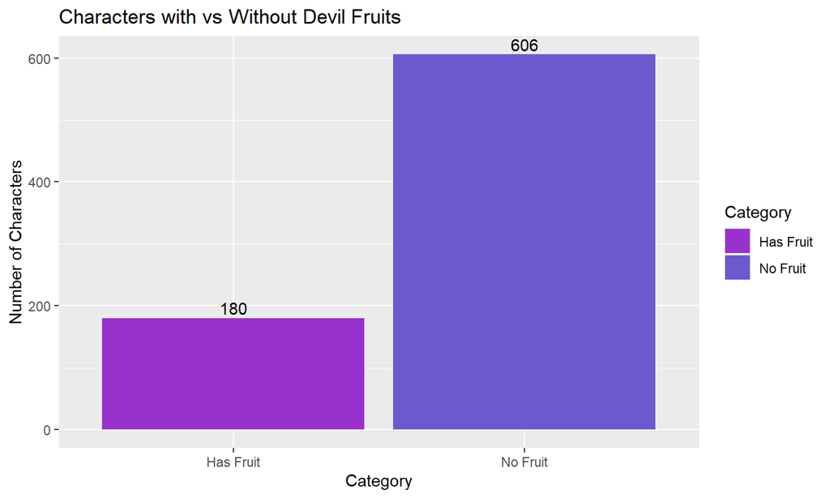

## Most Common Devil Fruit Types

- Compares different types of Devil Fruits
- Some types appear more frequently than others

Devil Fruit Types

Count of characters by fruit category

| Fruit Type | Count |
| --- | --- |
| Paramecia | 97 |
| Smile | 27 |
| Zoan | 21 |
| Logia | 13 |
| Zoan Mythique | 10 |
| Zoan Antique | 8 |
| Clone | 4 |

## Most common DF types (in a plot)

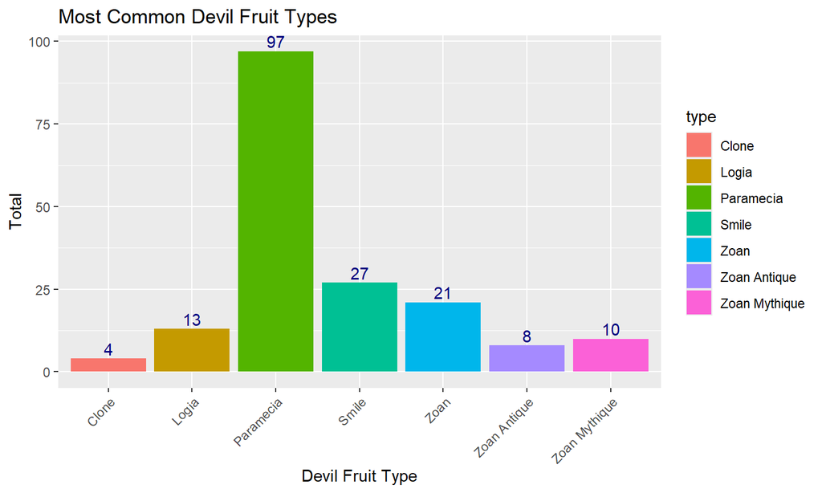

## Crews with Multiple Devil Fruit Users

- Shows crews with more than one user
- Highlights where Devil Fruits are more concentrated

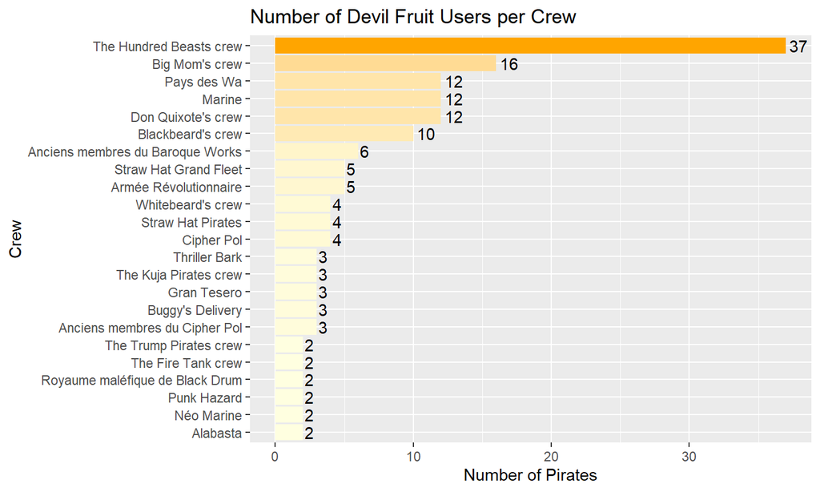

## Do Devil Fruits Affect Bounty?

- Devil Fruits provide strong abilites
- Bounties reflect danger and influence
- Do these two relate?

## Do Devil Fruit users have higher bounties?

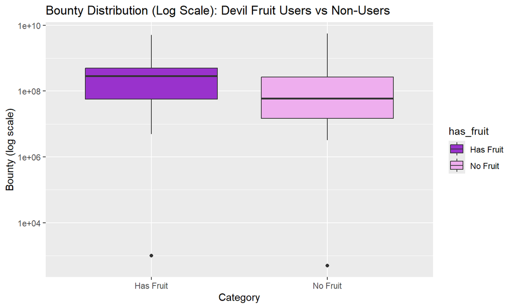

## Average bounty of Devil Fruit users vs non-users?

- devil fruit users have a higher bounty average
- further supports data seen in the box plot

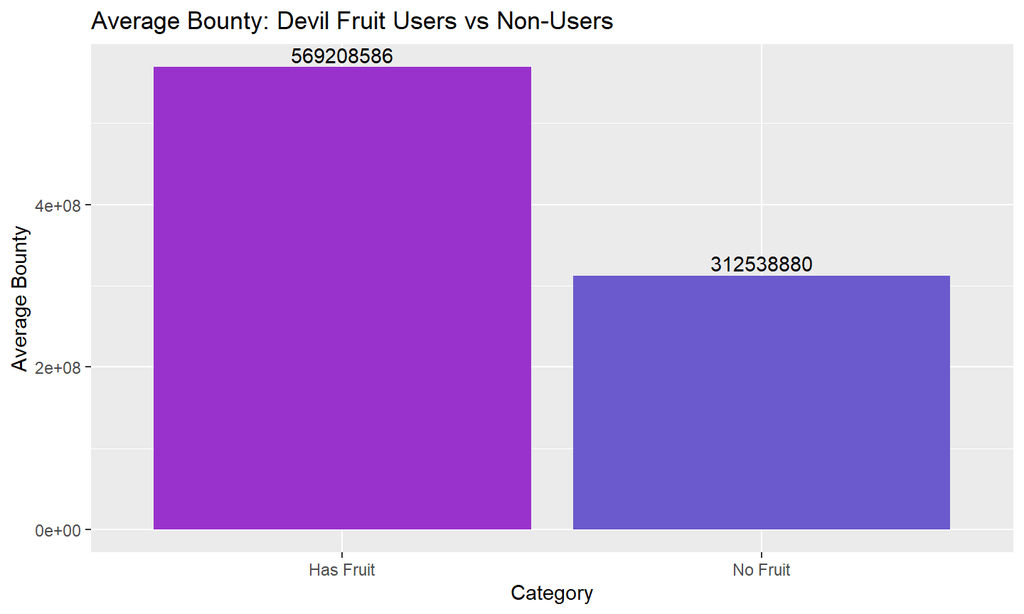

## Highest bounty characters without Devil Fruits?

- Strength and influence are not limited to Devil Fruit powers

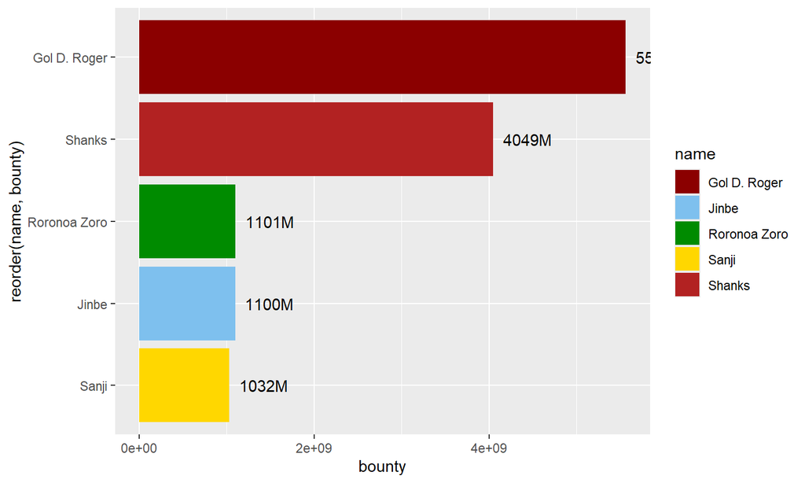

## Islands by Region

## East Blue vs North Blue

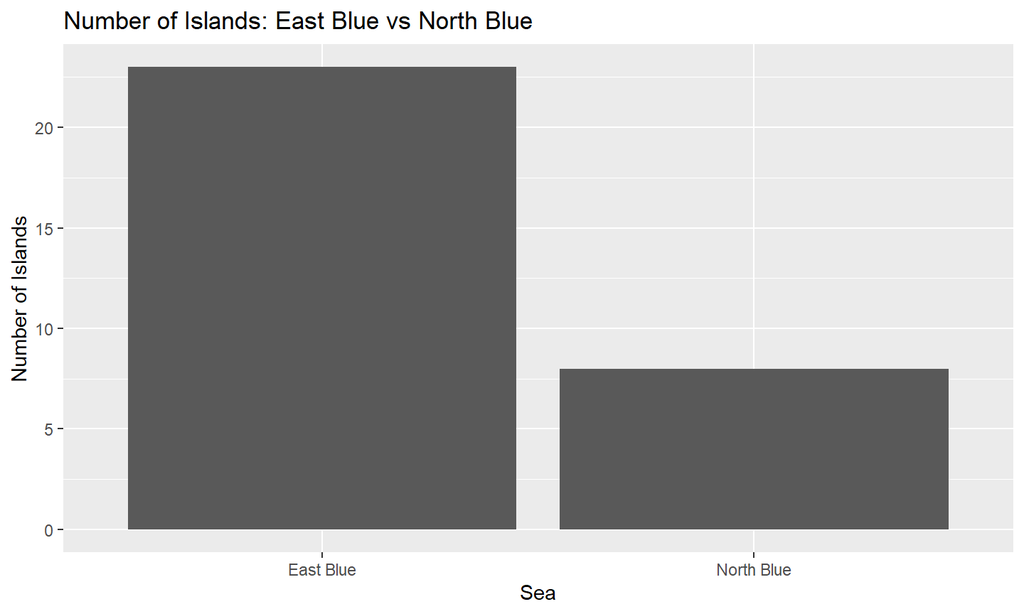

## Island Distribution by Region

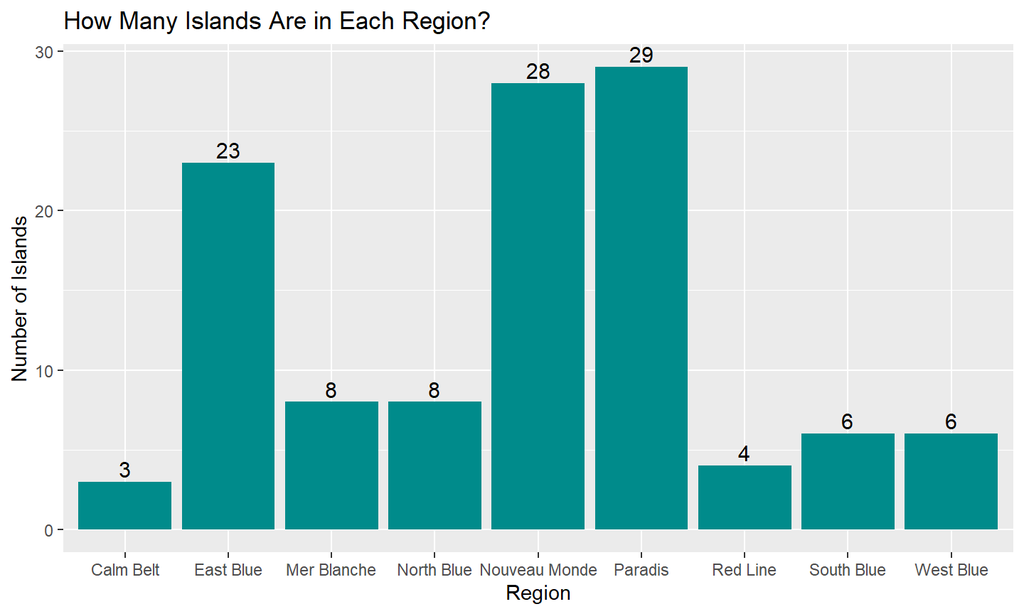

## Characters

## Characters in One Piece

- As we can see there are hundereds of characters in the One Piece Universe
- We were limited on time, but here are some more plots!

## Strawhat Crew Members

```
##   total_members
## 1            11
```

## Big Mom Crew vs Others

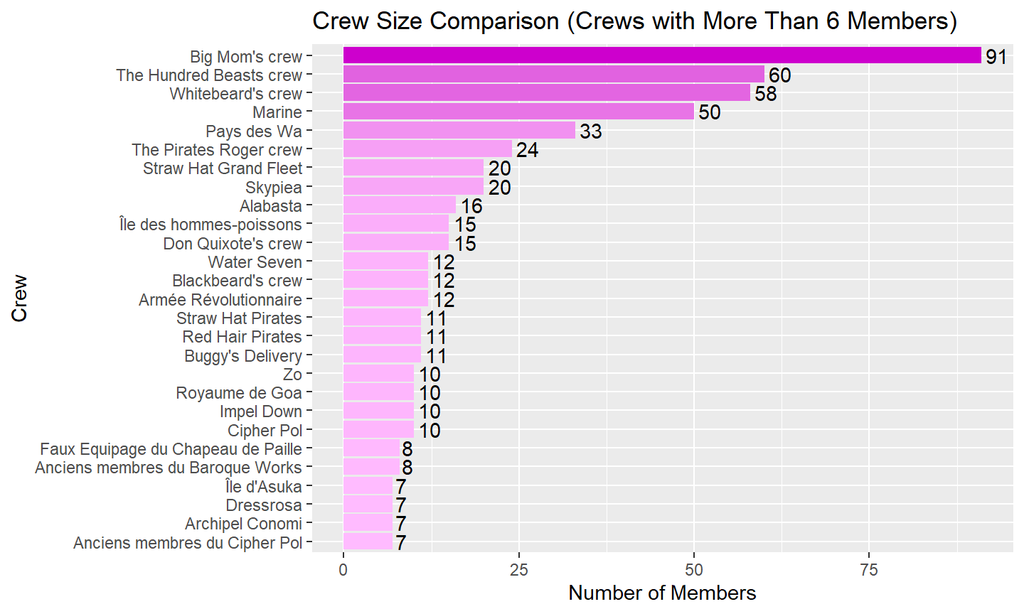

## Captains

```
##   total_captains
## 1             45
```

## Character Occupations

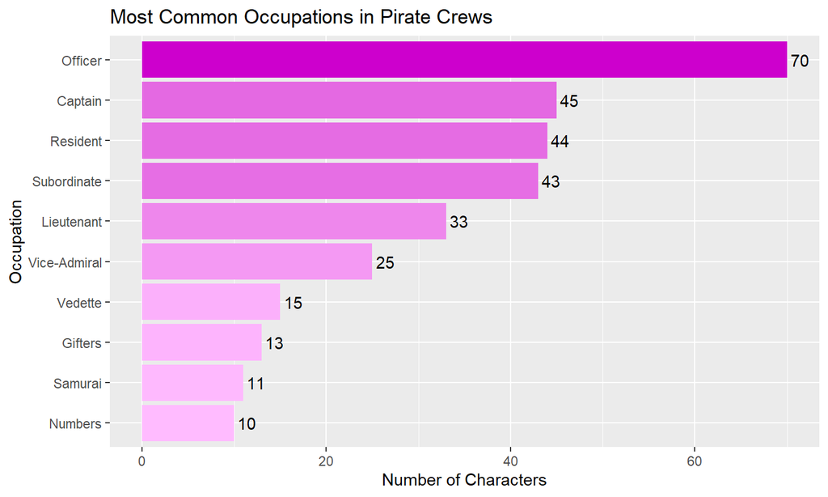

## Character Sizes

What is the distribution of height among the characters?

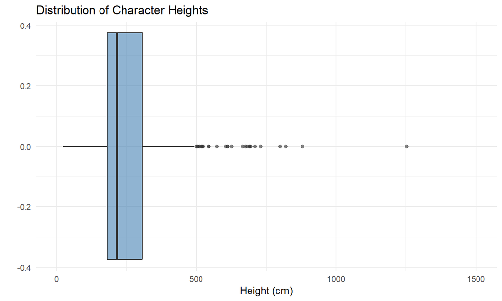

## Size Distribution (Density)

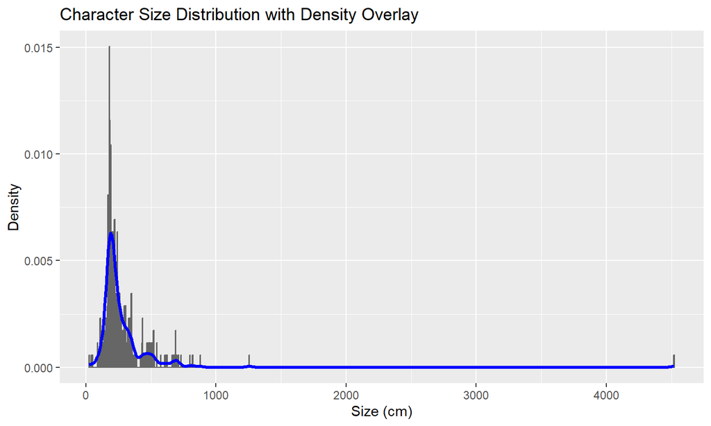

## Devil Fruit VS Non-Devil Fruit

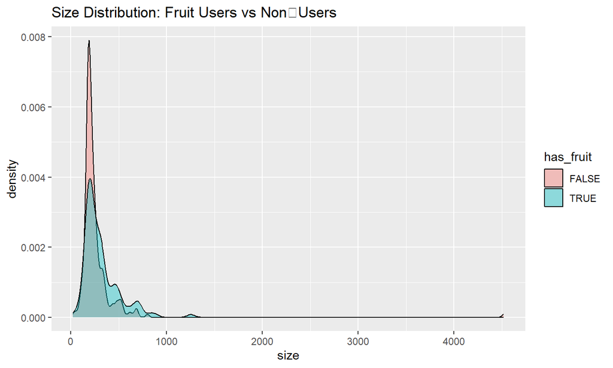

## Episodes

## Why look at episodes?

- As mentioned One Piece has been releasing since 1999
- At the moment of this presentation being made it has 1157 episodes, with many more manga chapters
- Along with the episodes there is arcs to the show

## How many episodes were released per decade?

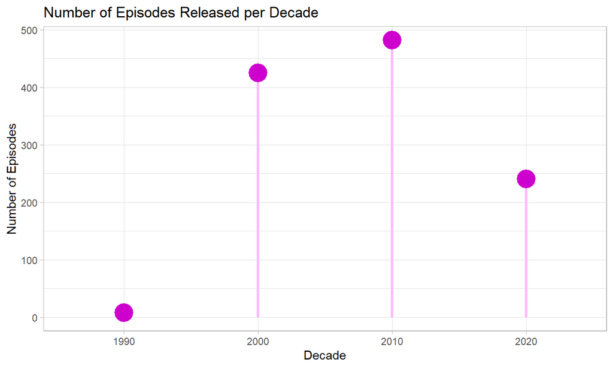

## Which Saga Has the Most Episodes?

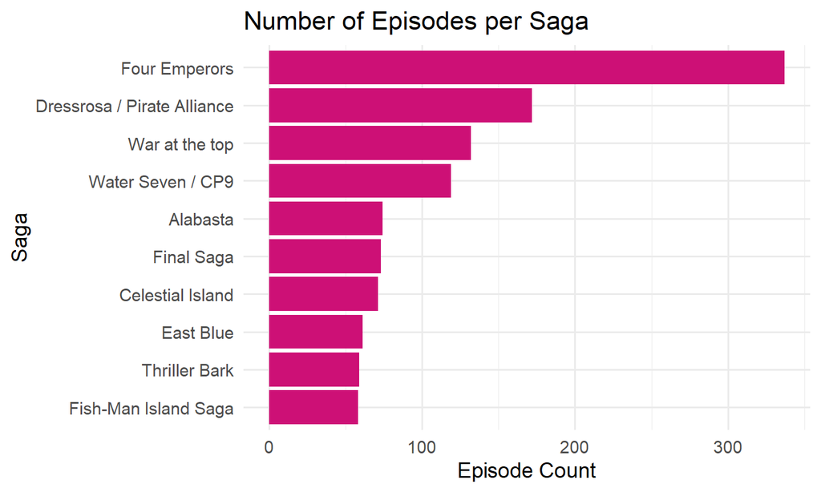

## Episodes per Year in each Saga

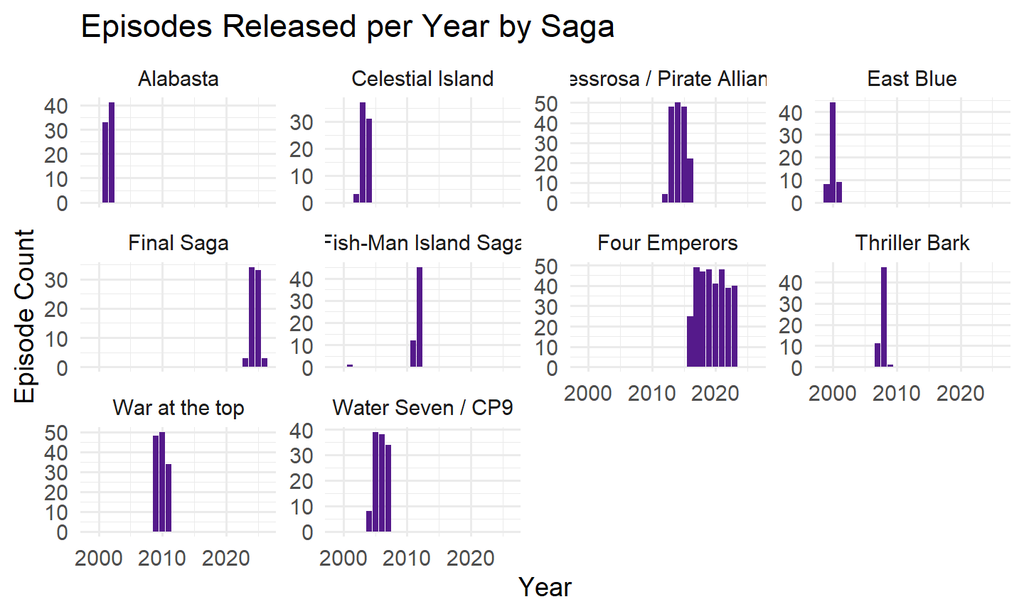

## That is all!

- Wish we had more time to work on more (and cooler) graphs
- Working with this One Piece API was definitely an experience